# Are intense hurricanse hurricnes become more intense?

# Methodology

The basis for all our work will be getting data from Hurdat2 data from NOAA. The hurdat2 data is reanalyixed and fixed for accuracy (http://www.aoml.noaa.gov/hrd/hurdat/hurdat_pub.html ref) so it should be fairly accurate, althought the latest year (2017) we not be availlable until 2018. First we need to calculate both ace and LMI.

### ACE

The formulat for ACE is expressed as:

$$ACE=10^{-4}\sum v_{\max}^{2}$$
vmax is the maximum sustained wind speed in knots. Sum refers to the sum of all observatiosn every 6 hours starting at 0000 and for the entire life of the storm as long as at meets the qualifiucations of Subtropical, Tropical Storm, Hurricane status while winds are greater than 39 mph.

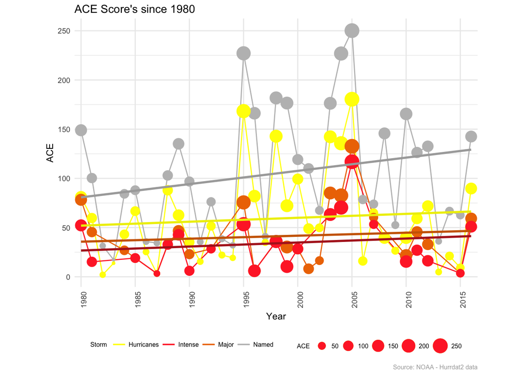

Figure 1. ACE Score for storms occuring 1980-2016

```r
year_ace_plot
```

Figure 1 shows the sume of all the ACE scores for each year. We are breaking the scores into each storm type and we see that all stroms show an upward trend in ACE.

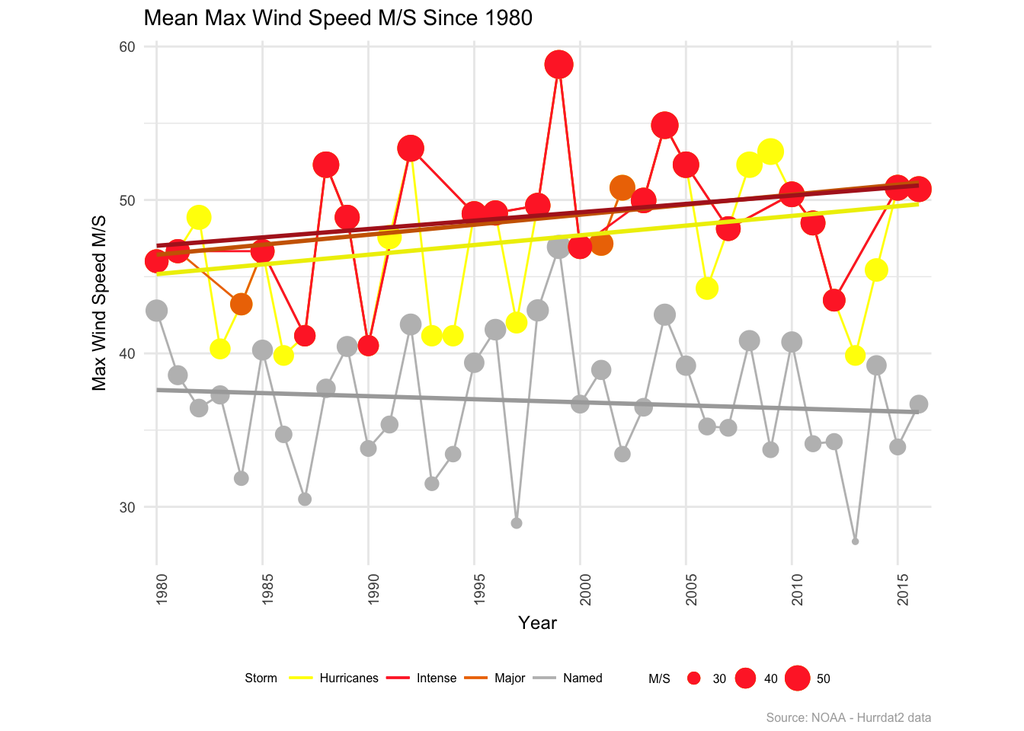

Figure 2. Mean Max Wind Speed Meters Per Seconds 1980 - 2016

```r
year_mean_plot
```

Figure 2 shows the mean maximun wind speed in meters per second for each year. We can look at each storm type and see that intense, major, and all hurricanes there seems to be an upward trend in winds. For all named storms it seem flat and perhaps there is downward trend.

```r
#only use named storms defined as Subtropical storms, Tropical Storms, and Hurricanes
#ace_subset <-  subset(hurr_obs, hurr_obs$status_code == 'SS' |  hurr_obs$status_code == 'HU' |  hurr_obs$status_code == 'TS')


#winds 39 MPH or greator (some Subtropical storms do not meet this)
#ace_subset <-  subset(ace_subset, ace_subset$wind_mph > 39)

#max wind every 6 hours tarting at 0000
#ace_subset <- subset(ace_subset, ace_subset$time == '0000' |  ace_subset$time == '0600' |  ace_subset$time == '1200' |  ace_subset$time == '1800')

#square the the max wind in knots
#ace_subset$wind_knts_sq <- ace_subset$wind_knts^2

#sum the squared winds
#sum_wind_knots <- aggregate(x=ace_sub$wind_knts_sq, by=list(ace_sub$storm_id, ace_sub$year),FUN=sum, na.rm=TRUE, na.action=NULL)

#multiple by 10 to -4 power.
#storm_ace$ace <- 10^-4*(sum_wind_knots$x)
```

### LMI

```r
#grid.arrange(p1, p2, ncol = 1)
```

```r
#hurr_obs$wind_meters_per_second <- as.numeric(as.numeric(hurr_obs$wind_knts) * 0.5144)
```

This provides easy ways to derive LMI and ACE for each storm and then summarize the data by year.

we also want to see how the effects that max wind m/s and ace have in each indivual year. we are expecting some very slight increases in intense hurricanes as we move foward in time. then we take the log on the max wind meters per second. I will use linear regresion to asses wether this true.

# Discussion

The preousi fuigures give us some insight into the possiblity that intense tropial systems are becoming more intense. This however does not provide us with any statistcal evidence of the increase.

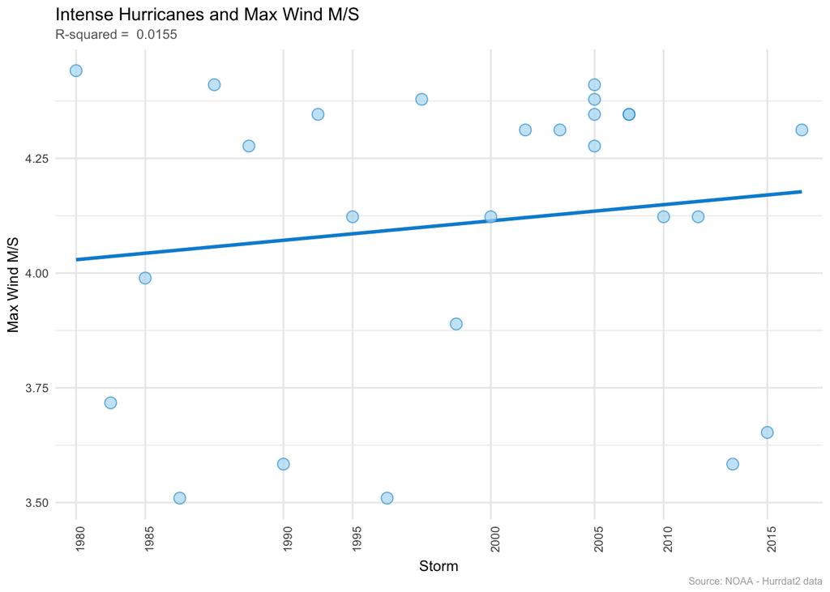

```r
scatter_intense_wind
```

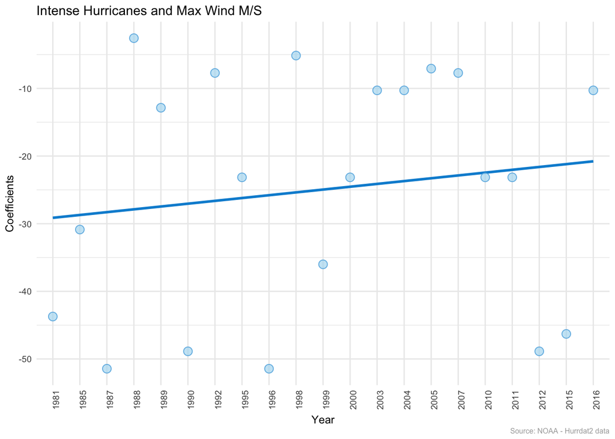

```r
scatter_intense_wind_coefficients
```

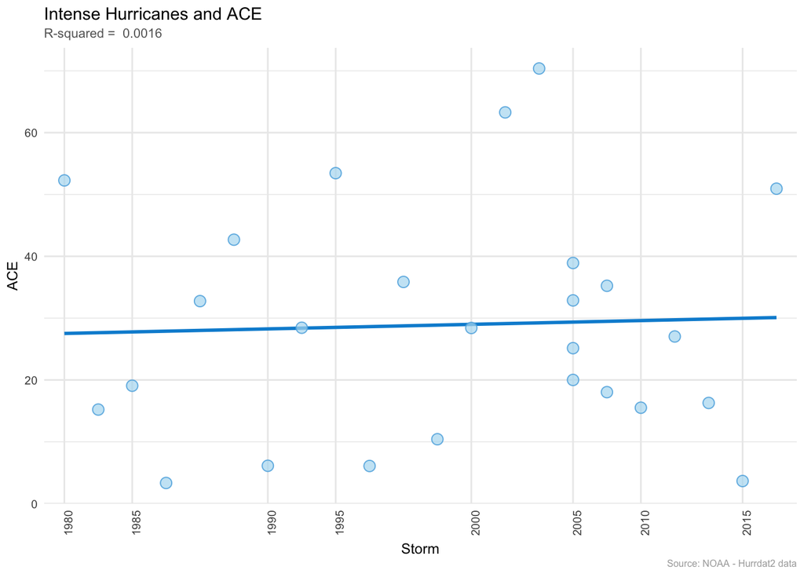

```r
scatter_intense_ace
```

For intense HUrricanes category 4 and 5

With ace we should not have to do any log nor use the coeffiences. ACE is and index that measures hte total intensity for the life time of the storm so it is arleady normailzied and ready for comapreis.

again we see a small trend updwards which suppports our inital hyothesis. The trend is smaller but that is expected ACE is intensity of the storms entire life. A storm that is intense for a long peroid of time is higher, and a storm that is weak that lasts for an extended period of time will also have a High ACE. ACE can show us small up ticks in intensity.

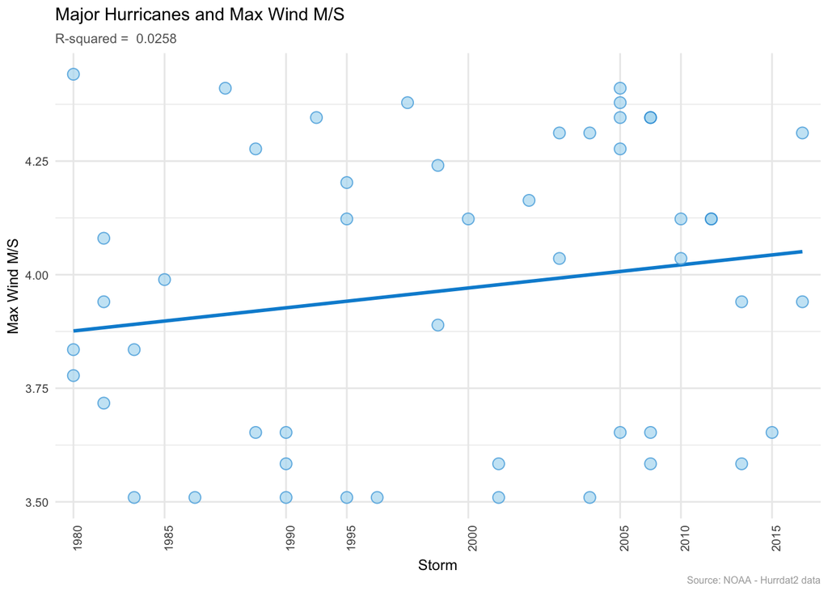

```r
scatter_major_wind
```

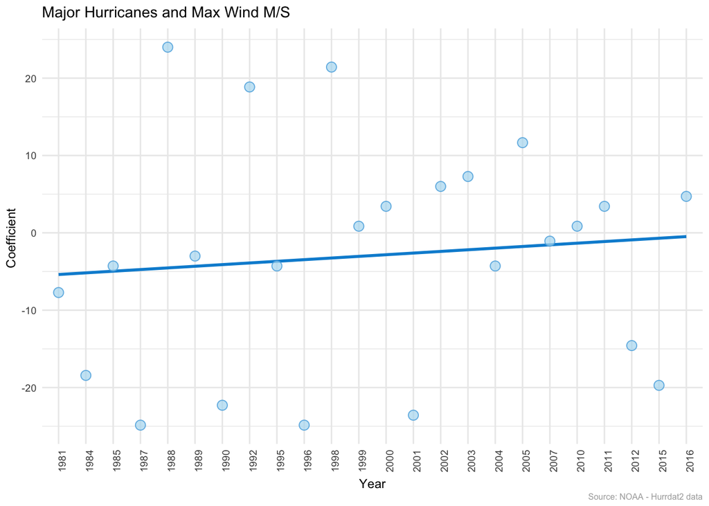

```r
scatter_major_wind_coefficients
```

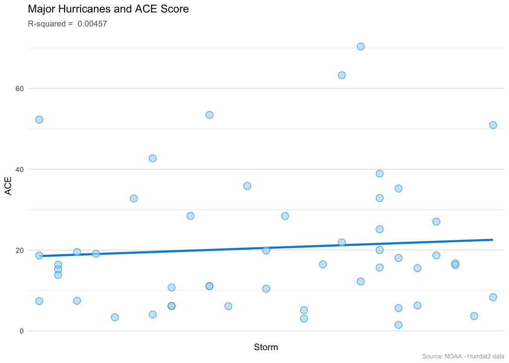

```r
scatter_major_ace
```

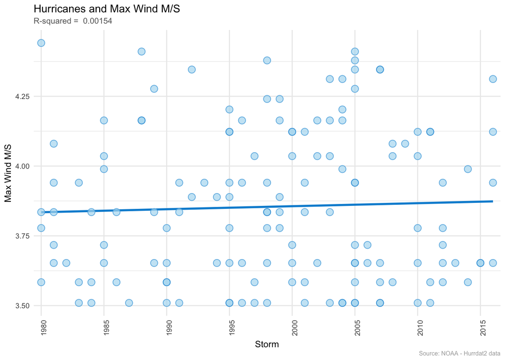

```r
scatter_hurricane_wind
```

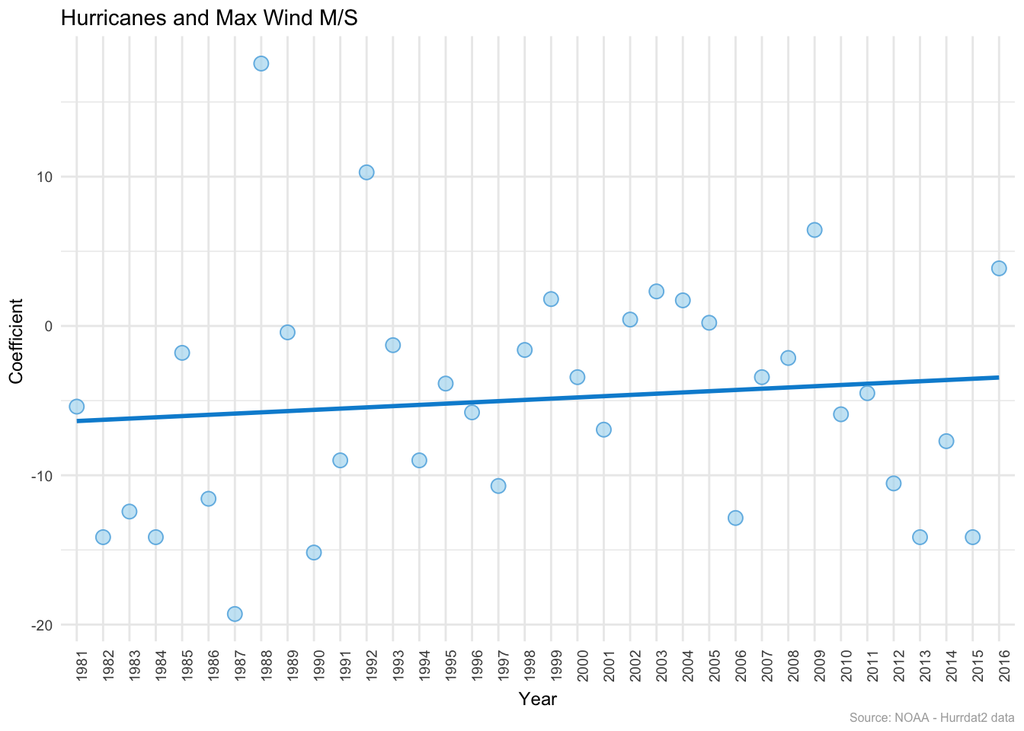

```r
scatter_hurricane_wind_coefficients
```

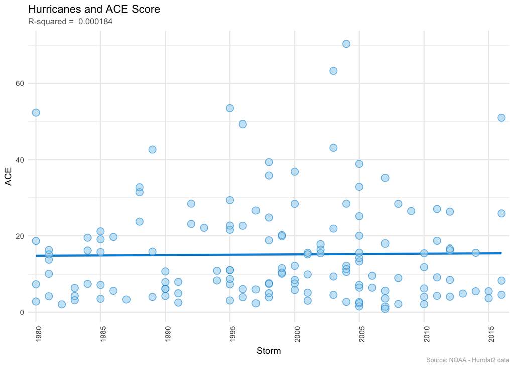

```r
scatter_hurricane_ace
```